# Monte Carlo Simulation of a Hypothesis Test Vignette

```r
library(Survive380AnnaTheBest)
library(ggplot2)
```

- Calculates the p_values under observed data and standard error using Monte Carlo sampling `Survive380AnnaTheBest::mc_pval_binom`
- Calculates the null p_value under null hypothesis `Survive380AnnaTheBest::mc_pval_null`
- Estimate Type I error `Survive380AnnaTheBest::mc_type1_binom`
- Estimate Type II error and power at a specific $p_{1}$ `Survive380AnnaTheBest::mc_power_simple_binom`
- Estimate power curve across a grid of $p$-value `Survive380AnnaTheBest::mc_power_curve_binom`

We will produce:

1. A summary table of Type I, Type II error and power
2. A histogram of simulated $p$-value with a vertical line at $\alpha$
3. A power curve plot

## Quick assumption check

Since we are using normal approximation to perform z-test, a common assumption is both $np_{0}$ and $n(1-p_{0})$ should be reasonably big ($\ge 10$)

```r
p_0 <- 0.5
n <- 50

c(np0 = n * p_0, n1p0 = n * (1 - p_0))
```

```
#>  np0 n1p0
#>   25   25
```

## Estimated $p$-value

### Computing $p$-value under a observation

```r
set.seed(1)
p_0 <- 0.5 # success probability
sample_size <- 50 # number of trials
alternative <- "less"
s_obs <- 20 # s_obs: number of success observed in one data set

p_value <- mc_pval_binom(
  p_0 = p_0,
  s_obs = s_obs,
  sample_size = sample_size,
  alternative = alternative
)

p_value$p_value
```

```
#> [1] 0.102969
```

```r
p_value$mc_se
```

```
#> [1] 0.0009610694
```

### Histogram of null $p$-value under $H_{0}$

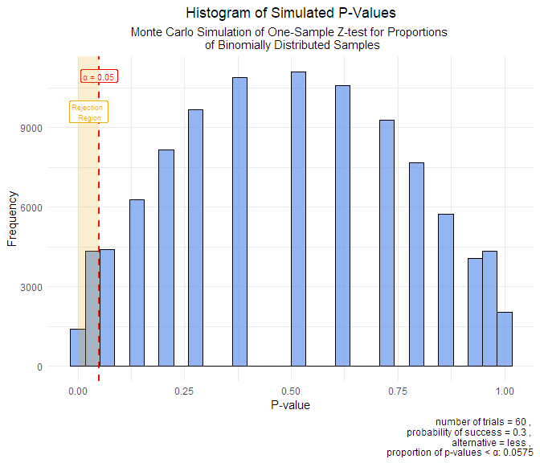

```r
# following code used to compute null p_value under H_0
set.seed(1)
p_0 <- 0.3
sample_size <- 60
alternative <- "less"

p_values <- mc_pval_null(
  p_0 = p_0,
  sample_size = sample_size,
  alternative = alternative
)

alpha <- 0.05  # significance level

rejections <- (p_values < alpha) # for checking rejection region (FYI)

# plot
ggplot(data.frame(p_value = p_values), aes(x = p_value)) +
  geom_histogram(bins = 30, fill = "cornflowerblue", color = "black", alpha = 0.7) +
  geom_vline(xintercept = alpha, color = "red", linetype = "dashed", linewidth = 1) +
  annotate(x = alpha, y = +Inf, label = paste("α =", alpha), vjust = 2,
           geom = "label", size = 3, color = "red") +
  # Add shaded rejection region
  annotate("rect", xmin = 0, xmax = alpha, ymin = 0, ymax = Inf,
           alpha = 0.2, fill = "darkgoldenrod2") +
  annotate(x = alpha/2, y = +Inf, label = paste("Rejection", "\n", "Region"),
           vjust = 3, geom = "label", size = 2.5, color = "darkgoldenrod2") +
  labs(title = "Histogram of Simulated P-Values",
       subtitle = paste("Monte Carlo Simulation of One-Sample Z-test for Proportions",
                        "\n" ,"of Binomially Distributed Samples"),
       caption = paste("number of trials =", sample_size, ", \n", "probability of success =", p_0,
                       ", \n", "alternative =", alternative, ", \n",
                       "proportion of p-values < α:", mean(p_values < alpha)),
       x = "P-value", y = "Frequency") +
  theme_minimal() +
  theme(plot.title = element_text(hjust = 0.5),
        plot.subtitle = element_text(hjust = 0.5))
```

## Estimated Type I error

```r
set.seed(1)
p_0 <- 0.5
sample_size <- 50
alternative <- "greater"

type1_rate <- mc_type1_binom(
  p_0 = p_0,
  sample_size = sample_size,
  alternative = alternative
)

type1_rate$type1_hat
```

```
#> [1] 0.05998
```

```r
type1_rate$mc_se
```

```
#> [1] 0.0007508821
```

## Estimated Type II error and power for a specific alternative value $p_{1}$

```r
set.seed(1)
p_0 <- 0.6
p_1 <- 0.4
sample_size <- 60
alternative <- "less"

power_type2 <- mc_power_simple_binom(
  p_0 = p_0,
  p_1 = p_1,
  sample_size = sample_size,
  alternative = alternative
)

power_type2$power_hat
```

```
#> [1] 0.9248
```

```r
power_type2$type2_hat
```

```
#> [1] 0.0752
```

```r
power_type2$power_mc_se
```

```
#> [1] 0.0008339362
```

```r
power_type2$type2_mc_se
```

```
#> [1] 0.0008339362
```

## Power Curve when alternative is not well-defined

```r
set.seed(1)
p_0 <- 0.6
sample_size <- 70
alternative <- "two_sided"

power_curve <- mc_power_curve_binom(
  p_0 = p_0,
  sample_size = sample_size,
  alternative = alternative
)

power_curve
```

```
#>    p_true power_hat type2_hat  power_mc_se  type2_mc_se
#> 1    0.30   0.99928   0.00072 8.482226e-05 8.482226e-05
#> 2    0.31   0.99831   0.00169 1.298901e-04 1.298901e-04
#> 3    0.32   0.99687   0.00313 1.766410e-04 1.766410e-04
#> 4    0.33   0.99510   0.00490 2.208164e-04 2.208164e-04
#> 5    0.34   0.99164   0.00836 2.879255e-04 2.879255e-04
#> 6    0.35   0.98705   0.01295 3.575234e-04 3.575234e-04
#> 7    0.36   0.97967   0.02033 4.462812e-04 4.462812e-04
#> 8    0.37   0.96857   0.03143 5.517441e-04 5.517441e-04
#> 9    0.38   0.95355   0.04645 6.655253e-04 6.655253e-04
#> 10   0.39   0.93515   0.06485 7.787456e-04 7.787456e-04
#> 11   0.40   0.90873   0.09127 9.107128e-04 9.107128e-04
#> 12   0.41   0.87786   0.12214 1.035480e-03 1.035480e-03
#> 13   0.42   0.84069   0.15931 1.157283e-03 1.157283e-03
#> 14   0.43   0.79469   0.20531 1.277332e-03 1.277332e-03
```

[output cut: 47 more lines]

### Plot of power curve (two sided)

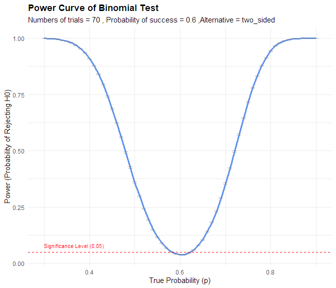

```r
ggplot(power_curve, aes(x = p_true,
                        y = power_hat)) +
  geom_line(color = "cornflowerblue",
            linewidth = 1.2) +
geom_errorbar(aes(
  ymin = pmax(0, power_hat - 2 * power_mc_se),
  ymax = pmin(1, power_hat + 2 * power_mc_se)),
                width = 0.01,
                color = "grey50",
                alpha = 0.5) +
  geom_hline(yintercept = 0.05,
             linetype = "dashed", color = "red") +
  annotate("text", x = min(power_curve$p_true),
           y = 0.08, label = "Significance Level (0.05)",
           color = "red",
           hjust = 0,
           size = 3) +
  labs(title = "Power Curve of Binomial Test",
       subtitle = paste("Numbers of trials =", sample_size,
                        ", Probability of success =", p_0,
                        ",Alternative =", alternative),
       x = "True Probability (p)",
       y = "Power (Probability of Rejecting H0)") +
  theme_minimal() +
  theme(plot.title = element_text(face = "bold"))
```

### Power Curve when alternative is greater

```r
set.seed(1)
p_0 <- 0.6
sample_size <- 70

alternative_one_sided <- "greater"

power_curve_one_sided <- mc_power_curve_binom(
  p_0 = p_0,
  sample_size = sample_size,
  alternative = alternative_one_sided
)

power_curve_one_sided
```

```
#>    p_true power_hat type2_hat  power_mc_se  type2_mc_se
#> 1    0.60   0.05530   0.94470 7.227857e-04 7.227857e-04
#> 2    0.61   0.07631   0.92369 8.395641e-04 8.395641e-04
#> 3    0.62   0.10210   0.89790 9.574737e-04 9.574737e-04
#> 4    0.63   0.13847   0.86153 1.092227e-03 1.092227e-03
#> 5    0.64   0.17994   0.82006 1.214749e-03 1.214749e-03
#> 6    0.65   0.22633   0.77367 1.323271e-03 1.323271e-03
#> 7    0.66   0.28624   0.71376 1.429359e-03 1.429359e-03
#> 8    0.67   0.34447   0.65553 1.502699e-03 1.502699e-03
#> 9    0.68   0.41442   0.58558 1.557806e-03 1.557806e-03
#> 10   0.69   0.48621   0.51379 1.580537e-03 1.580537e-03
#> 11   0.70   0.55844   0.44156 1.570302e-03 1.570302e-03
#> 12   0.71   0.63061   0.36939 1.526241e-03 1.526241e-03
#> 13   0.72   0.69983   0.30017 1.449372e-03 1.449372e-03
#> 14   0.73   0.76265   0.23735 1.345418e-03 1.345418e-03
```

[output cut: 17 more lines]

### Plot of power curve (greater)

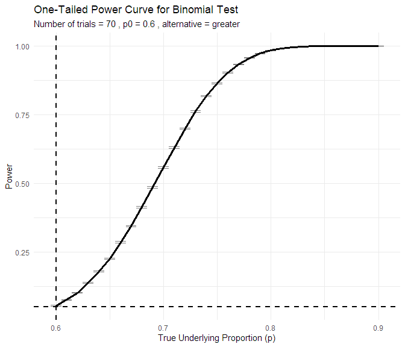

```r
alpha_level <- 0.05
alternative <- alternative_one_sided

ggplot(power_curve_one_sided, aes(x = p_true, y = power_hat)) +
  geom_line(linewidth = 1.2) +
  geom_errorbar(
    aes(
      ymin = pmax(0, power_hat - 2 * power_mc_se),
      ymax = pmin(1, power_hat + 2 * power_mc_se)
    ),
    width = 0.01,
    alpha = 0.5
  ) +
  geom_vline(xintercept = p_0, linetype = "dashed", linewidth = 1) +
  geom_hline(yintercept = alpha_level, linetype = "dashed", linewidth = 0.8) +
  labs(
    title = "One-Tailed Power Curve for Binomial Test",
    subtitle = paste(
      "Number of trials =", sample_size,
      ", p0 =", p_0,
      ", alternative =", alternative
    ),
    x = "True Underlying Proportion (p)",
    y = "Power"
  ) +
  theme_minimal()
```

## Power vs. Sample Size Curve

```r
#This indicates the sample size required to achieve the desired test capability.
# Here, we use 80% as an example.

#set initials
sample_sizes <- seq(10, 200, by = 10)
M <- 1000
p_true <- 0.65
p_null <- 0.5
alpha <- 0.05
power_results <- numeric(length(sample_sizes))

for(i in 1:length(sample_sizes)) {
  n <- sample_sizes[i]
  p_hat <- rbinom(M, n, p_true) / n
  z_stats <- (p_hat - p_null) / sqrt(p_null * (1 - p_null) / n)
  p_values <- 2 * pnorm(-abs(z_stats))
  power_results[i] <- mean(p_values < alpha)
}
df_power <- matrix(c(sample_sizes, power_results),
                   ncol = 2,
                   dimnames = list(NULL, c("SampleSize", "Power")))
achieved_target <- df_power[df_power[, "Power"] >= 0.8, , drop = FALSE]
if (nrow(achieved_target) > 0) {
  required_n <- achieved_target[1, "SampleSize"]
  cat("To achieve 80% test power，we need at least n =", required_n, "\n")
} else {
  cat("fail to reach 80% test power，please enhance the sample size \n")
}
```

```
#> To achieve 80% test power，we need at least n = 80
```

### Plot of Power vs. Sample Size Curve

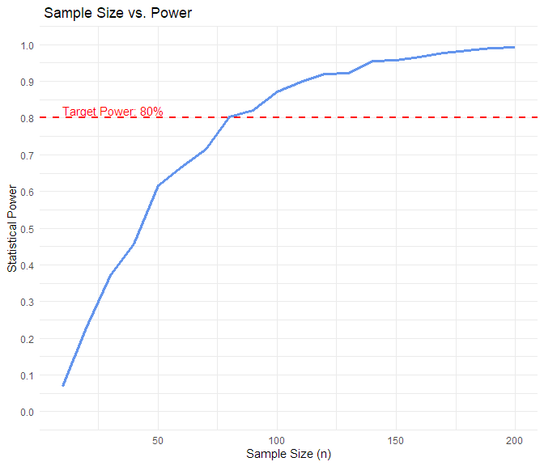

```r
ggplot(as.data.frame(df_power), aes(x = SampleSize, y = Power)) +
  geom_line(color = "cornflowerblue", linewidth = 1.2) +

  geom_hline(yintercept = 0.8,
             linetype = "dashed",
             color = "red",
             linewidth = 0.8) +

  annotate("text", x = min(df_power[, "SampleSize"]),
           y = 0.82,
           label = "Target Power: 80%", color = "red", hjust = 0) +

  labs(title = " Sample Size vs. Power",
       x = "Sample Size (n)",
       y = "Statistical Power") +
  scale_y_continuous(breaks = seq(0, 1, 0.1), limits = c(0, 1)) +
  theme_minimal()
```

## Summary table

```r
summary_tab <- data.frame(
  Quantity = c("Type I error", "Power", "Type II error"),
  Estimate = c(type1_rate$type1_hat, power_type2$power_hat, power_type2$type2_hat),
  MC_SE    = c(type1_rate$mc_se, power_type2$power_mc_se, power_type2$type2_mc_se)
)
summary_tab
```

```
#>        Quantity Estimate        MC_SE
#> 1  Type I error  0.05998 0.0007508821
#> 2         Power  0.92480 0.0008339362
#> 3 Type II error  0.07520 0.0008339362
```

## Generative AI Usage Statement

Generative AI was used in the following areas:

- debugging parts of Function_Code and Testing_Code;
- assisting in plot creation using ggplot2;
- helping to build up Bibliography;
- determining what should be contained in a ‘good’ roxygen documents and to provide some examples of roxygen;
- debugging package compilation errors and notes;
- helping to build the UI for Rshiny app;
- helping to create manifest.json and ui-latex.R file;
- helping to choose color for the website;
- help to write the README, lol.

## Bibliography

Lehmann, Erich L., and Joseph P. Romano. 2005. *Testing Statistical Hypotheses*. 3rd ed. Springer.

R Core Team. 2024. *R: A Language and Environment for Statistical Computing*. Vienna, Austria: R Foundation for Statistical Computing.

Robert, Christian P., and George Casella. 2004. *Monte Carlo Statistical Methods*. 2nd ed. Springer.

Wickham, Hadley. 2016. *Ggplot2: Elegant Graphics for Data Analysis*. Springer.

Xie, Yihui. 2015. *Dynamic Documents with r and Knitr*. 2nd ed. Chapman; Hall/CRC.

Xie, Yihui, J. J. Allaire, and Garrett Grolemund. 2018. *R Markdown: The Definitive Guide*. Chapman; Hall/CRC.